# Premier Hockey Federation Shots - Solutions

**Click for solution**

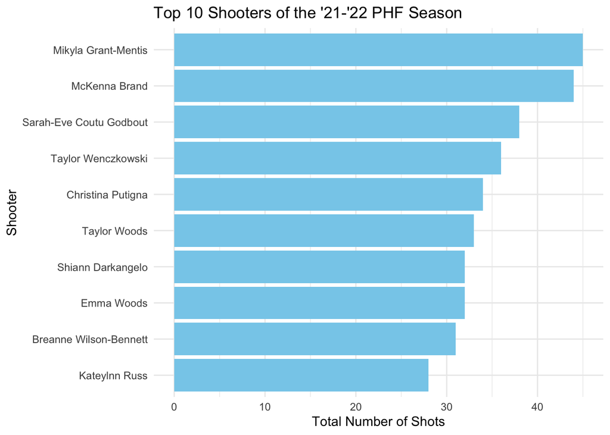

```r
top10_shooters <- phf_shots |>
  rename(shooter = player_name_1) |>
  group_by(shooter) |>
  summarise(total_shots = n()) |>
  arrange(desc(total_shots)) |>
  slice(1:10) |>
  mutate(shooter = fct_reorder(shooter, total_shots))

ggplot(data = top10_shooters, aes(x = shooter, y = total_shots)) +
  geom_col(fill = "skyblue") +
  coord_flip() +
  theme_minimal() +
  labs(title = "Top 10 Shooters of the '21-'22 PHF Season",
       y = "Total Number of Shots",
       x = "Shooter")
```

7. In hockey, save proportion measures how often a goalie successfully stops shots on goal. Shots on goal consist of shots that are recorded as “made” or “saved”, but do not include shots “blocked” as these are shots blocked by other defense players, not the goalie. Save proportion is calculated as the goalie’s (shots saved) / (total shots on goal).
1. Using some dplyr and/or tidyr functions, create a data frame with each goalie’s save proportion.

Hint: The variables of interest here are `goalie_involved` (which shows the names of goalies) and `shot_result`, which has categories: blocked, made, saved. Since this exploration excludes blocked shots, start by filtering to exclude them.

**Click for solution**

```r
phf_goalies <- phf_shots |>
  filter(shot_result != "blocked") |>
  group_by(goalie_involved) |>
  summarise(
    shots_on_goal = n(),
    total_goals = sum(shot_result == "made"),
    total_saves = sum(shot_result == "saved"),
    save_prop = total_saves / shots_on_goal
  )

phf_goalies
```

```
# A tibble: 18 × 5
   goalie_involved           shots_on_goal total_goals total_saves save_prop
   <chr>                             <int>       <int>       <int>     <dbl>
 1 Abbie Ives                           95          11          84     0.884
 2 Abbie Ives replaced by #1            18           2          16     0.889
 3 Abbie Ives replaced by #3             8           3           5     0.625
 4 Allie Morse replaced by #            30           3          27     0.9
 5 Amanda Leveille                     202          12         190     0.941
 6 Brooke Wolejko                        6           2           4     0.667
 7 Brooke Wolejko replaced b             4           0           4     1
 8 Carly Jackson                       186          18         168     0.903
 9 Carly Jackson replaced by            12           3           9     0.75
10 Elaine Chuli                        147          14         133     0.905
11 Elaine Chuli replaced by              4           1           3     0.75
12 Lovisa Selander                     188          12         176     0.936
13 Lovisa Selander replaced              4           0           4     1
14 Samantha Ridgewell                   26           6          20     0.769
15 Sonjia Shelly                        77           1          76     0.987
16 Tera Hofmann                         36           3          33     0.917
17 Victoria Hanson                      58           5          53     0.914
18 <NA>                                  3           3           0     0
```

2. You should notice an NA value under `goalie_involved` after completing this. Remove the row with that NA value from the final data frame.

**Click for solution**

```r
phf_goalies <- phf_goalies |>
  filter(!is.na(goalie_involved))

phf_goalies
```

```
# A tibble: 17 × 5
   goalie_involved           shots_on_goal total_goals total_saves save_prop
   <chr>                             <int>       <int>       <int>     <dbl>
 1 Abbie Ives                           95          11          84     0.884
 2 Abbie Ives replaced by #1            18           2          16     0.889
 3 Abbie Ives replaced by #3             8           3           5     0.625
 4 Allie Morse replaced by #            30           3          27     0.9
 5 Amanda Leveille                     202          12         190     0.941
 6 Brooke Wolejko                        6           2           4     0.667
 7 Brooke Wolejko replaced b             4           0           4     1
 8 Carly Jackson                       186          18         168     0.903
 9 Carly Jackson replaced by            12           3           9     0.75
10 Elaine Chuli                        147          14         133     0.905
11 Elaine Chuli replaced by              4           1           3     0.75
12 Lovisa Selander                     188          12         176     0.936
13 Lovisa Selander replaced              4           0           4     1
14 Samantha Ridgewell                   26           6          20     0.769
15 Sonjia Shelly                        77           1          76     0.987
16 Tera Hofmann                         36           3          33     0.917
17 Victoria Hanson                      58           5          53     0.914
```

3. You should also notice that the `goalie_involved` variable includes entries like “Allie Morse replaced by #”. Filter using `goalie_involved %in% c()` where `c()` takes the names of goalies without “replaced…” entries.

**Click for solution**

```r
phf_goalies <- phf_goalies |>
  filter(goalie_involved %in% c(
    "Abbie Ives", "Amanda Leveille", "Brooke Wolejko",
    "Carly Jackson", "Elaine Chuli", "Samantha Ridgewell",
    "Sonjia Shelly", "Tera Hofmann", "Victoria Hanson"
  ))

phf_goalies
```

```
# A tibble: 9 × 5
  goalie_involved    shots_on_goal total_goals total_saves save_prop
  <chr>                      <int>       <int>       <int>     <dbl>
1 Abbie Ives                    95          11          84     0.884
2 Amanda Leveille              202          12         190     0.941
3 Brooke Wolejko                 6           2           4     0.667
4 Carly Jackson                186          18         168     0.903
5 Elaine Chuli                 147          14         133     0.905
6 Samantha Ridgewell            26           6          20     0.769
7 Sonjia Shelly                 77           1          76     0.987
8 Tera Hofmann                  36           3          33     0.917
9 Victoria Hanson               58           5          53     0.914
```

8. Using the data frame from your answer to Question 7c above, create a visualization of your choice to display goalies’ save proportions in ascending order. Use `coord_flip()` such that the goalie variable is on the y axis and save proportion is on the x axis. Remember to use descriptive axis labels and a title.

**Click for solution**

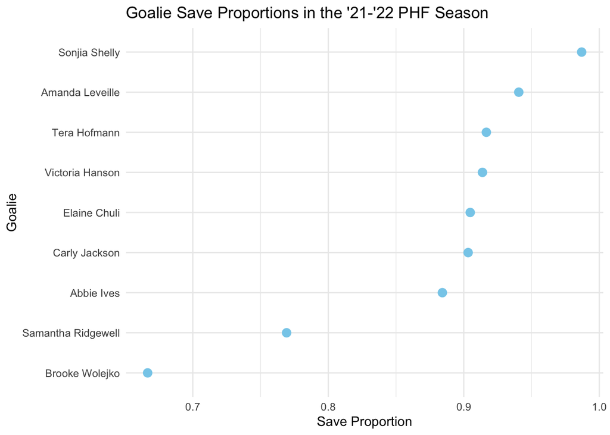

```r
# A lollipop plot, bar plot, or dot plot would all work here.

phf_goalies <- phf_goalies |>
  mutate(goalie_involved = fct_reorder(goalie_involved, save_prop))

ggplot(phf_goalies, aes(x = save_prop, y = goalie_involved)) +
  geom_point(size = 3, colour = "skyblue") +
  theme_minimal() +
  labs(title = "Goalie Save Proportions in the '21-'22 PHF Season",
       x = "Save Proportion",
       y = "Goalie")
```

9. So far, we have compared goalies using ordered plots. Another useful way to understand data is by examining its distribution.
1. Using the `phf_goalies` data frame from Question 7c, create a histogram of goalie save proportions. Choose an appropriate bin width, and include a title and axis labels.

**Click for solution**

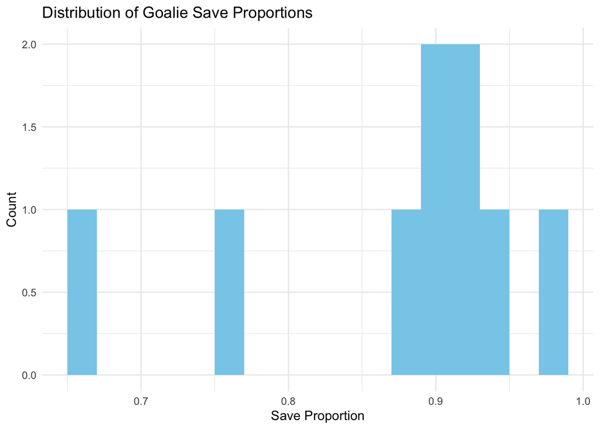

```r
ggplot(phf_goalies, aes(x = save_prop)) +
  geom_histogram(binwidth = 0.02, fill = "skyblue") +
  theme_minimal() +
  labs(title = "Distribution of Goalie Save Proportions",
       x = "Save Proportion",
       y = "Count")
```

2. Based on your histogram, describe the distribution of save proportions. In your answer, consider the following:
- Is the distribution symmetric, left-skewed, or right-skewed?
- Are there any noticeable outliers?

**Click for solution**

Most goalies have a save proportion between about 0.87 and 0.95. The distribution is left-skewed, with one goalie posting a save proportion below 0.70 — a potential outlier well below the rest of the group.